# 🛍️ Retail Strategy Simulation Report

**Agent-Based Modeling in NetLogo**  
**Analyzed Using Python – Jupyter Notebook**  
**Number of Customers per Experiment: 250**

This report presents the results of three simulation scenarios testing the effects of different strategies (Marketing, Employee Training, Product Variety) on store performance using cumulative sales as the main metric.

```python
import pandas as pd
import matplotlib.pyplot as plt
import seaborn as sns
from scipy.stats import ttest_rel

# Set plot style
sns.set(style='whitegrid', palette='muted')

# Function to process and plot each scenario
def analyze_scenario(filename, title):
    print(f"\n{'='*30}\nScenario: {title}\n{'='*30}")

    # Load data
    df = pd.read_excel(filename)

    # Rename columns if needed
    df.columns = ['x0', 'y0', 'x1', 'y1']

    # Plot cumulative sales
    plt.figure(figsize=(10, 5))
    plt.plot(df['x0'], df['y0'], label='Store 0 (Boosted)', linewidth=2)
    plt.plot(df['x1'], df['y1'], label='Store 1 (Baseline)', linewidth=2, linestyle='--')
    plt.title(f'Cumulative Sales: {title}')
    plt.xlabel('Days Passed')
    plt.ylabel('Cumulative Sales')
    plt.legend()
    plt.tight_layout()
    plt.show()

    # Final cumulative sales
    final_store0 = df['y0'].iloc[-1]
    final_store1 = df['y1'].iloc[-1]
    print(f"Final Cumulative Sales:")
    print(f"Store 0 (Boosted): {final_store0:.2f}")
    print(f"Store 1 (Baseline): {final_store1:.2f}")

    # % Difference
    if final_store1 > 0:
        perc_diff = ((final_store0 - final_store1) / final_store1) * 100
        print(f"→ Store 0 outperformed Store 1 by {perc_diff:.2f}%\n")
    else:
        print("→ Store 1 has 0 sales — no valid percentage comparison.\n")

    # Paired t-test on day-by-day cumulative sales
    stat, p_value = ttest_rel(df['y0'], df['y1'])
    print("Paired t-test on daily cumulative sales:")
    print(f"t-statistic = {stat:.4f}, p-value = {p_value:.4f}")
    if p_value < 0.05:
        print("→ Statistically significant difference between stores (p < 0.05)\n")
    else:
        print("→ No statistically significant difference (p ≥ 0.05)\n")
```

## 📊 Scenario 1: Marketing-Driven Strategy (New Store Launch)

**Objective:**  
Test whether increased marketing helps a new store gain a competitive edge in a short-term, high-exposure setting.

**Simulation Settings:**

- **Number of Days (Ticks):** 90
- **Customer Preference Weights:**
  - Employee Training: 30%
  - Product Variety: 20%
  - Marketing: 50%
- **Store 0 (Boosted):** Marketing = 80–100
- **Store 1 (Baseline):** All factors = 50

**📈 Chart:**

```
==============================
Scenario: Marketing-Driven Strategy (New Store)
==============================
```

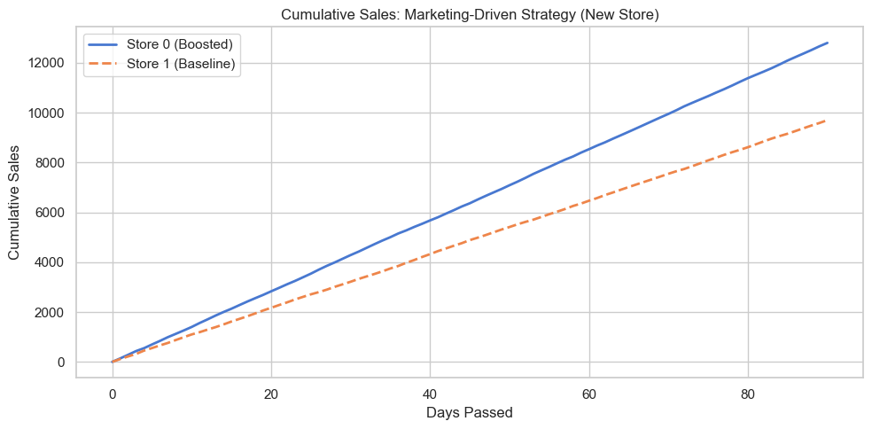

```
Final Cumulative Sales:
Store 0 (Boosted): 12800.00
Store 1 (Baseline): 9700.00
→ Store 0 outperformed Store 1 by 31.96%

Paired t-test on daily cumulative sales:
t-statistic = 16.1277, p-value = 0.0000
→ Statistically significant difference between stores (p < 0.05)
```

```python
analyze_scenario('NewStore_store-2plot.xlsx', 'Marketing-Driven Strategy (New Store)')
```

## 🏪 Scenario 2: Service-Oriented Strategy (Luxury/Niche Boutique)

**Objective:**  
Evaluate if better-trained employees lead to stronger long-term performance and customer loyalty.

**Simulation Settings:**

- **Number of Days (Ticks):** 730
- **Customer Preference Weights:**
  - Employee Training: 45%
  - Product Variety: 25%
  - Marketing: 30%
- **Store 0 (Boosted):** Employee Training = 80–100
- **Store 1 (Baseline):** All factors = 50

**📈 Chart:**

```
==============================
Scenario: Service-Oriented Strategy (Luxury/Niche)
==============================
```

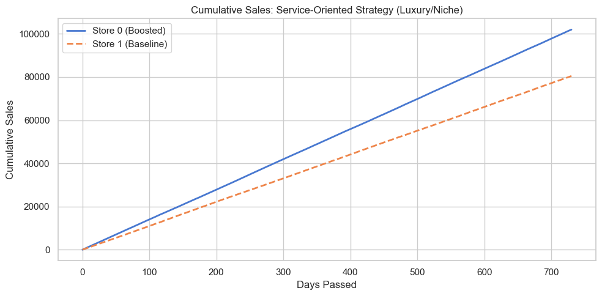

```
Final Cumulative Sales:
Store 0 (Boosted): 101992.00
Store 1 (Baseline): 80508.00
→ Store 0 outperformed Store 1 by 26.69%

Paired t-test on daily cumulative sales:
t-statistic = 46.4921, p-value = 0.0000
→ Statistically significant difference between stores (p < 0.05)
```

```python
analyze_scenario('LuxStore_store-2plot.xlsx', 'Service-Oriented Strategy (Luxury/Niche)')
```

## 🛒 Scenario 3: Product Variety Focused Strategy (High-Traffic Retail)

**Objective:**  
Assess if increasing product diversity attracts more customers and drives higher sales in a high-traffic setting.

**Simulation Settings:**

- **Number of Days (Ticks):** 365
- **Customer Preference Weights:**
  - Employee Training: 25%
  - Product Variety: 40%
  - Marketing: 35%
- **Store 0 (Boosted):** Product Variety = 80–100
- **Store 1 (Baseline):** All factors = 50

**📈 Chart:**

```
==============================
Scenario: Product Variety Focused Strategy (High-Traffic)
==============================
```

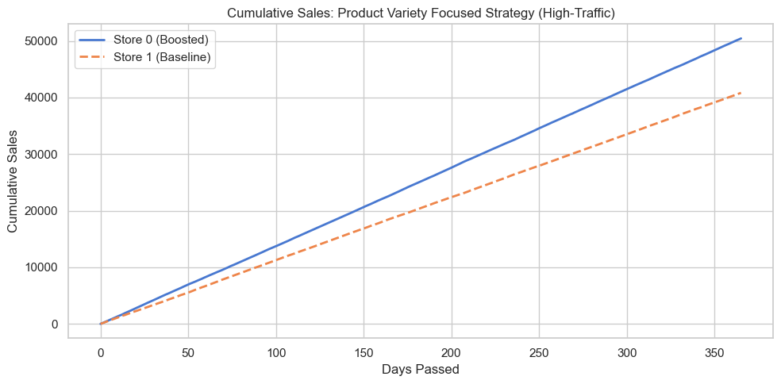

```
Final Cumulative Sales:
Store 0 (Boosted): 50435.00
Store 1 (Baseline): 40815.00
→ Store 0 outperformed Store 1 by 23.57%

Paired t-test on daily cumulative sales:
t-statistic = 32.3462, p-value = 0.0000
→ Statistically significant difference between stores (p < 0.05)
```

```python
analyze_scenario('GroceryStore_store-2plot.xlsx', 'Product Variety Focused Strategy (High-Traffic)')
```

## 📌 Overall Conclusion

Each strategic focus (Marketing, Training, Product Variety) demonstrated a **clear and statistically significant impact** on store performance when optimized in the model. The strongest relative improvement was observed in the marketing-driven short-term scenario, while employee training produced the highest **absolute sales gain** over time.

These findings suggest that:

- **Marketing is highly effective for short-term gains and visibility.**
- **Employee training builds stronger long-term loyalty and repeat purchases.**
- **Product variety attracts diverse traffic and sustains moderate growth.**

👉 The best approach depends on store goals (e.g., launch success vs. long-term loyalty vs. foot traffic conversion).

**Prepared by:**

- Ahmed Essam | Ahmed.Essam2021@feps.edu.eg | 5210686
- Abrar Mabrouk | abrar.mabrouk2020@feps.edu.eg | 5200964
- Noor Hossameldin | Noor.Hossameldin2020@feps.edu.eg | 5200728

Under the supervision of Dr. Rasha Hasan